# Cortical bone strength at the tibial shaft in healthy adults

Dataset 12: Muscle power and tibial bone strength in healthy adults

RSR feasibility analysis

2026-08-03

# Introduction

This is a cross-sectional laboratory study of 142 healthy adults recruited as a convenience sample from the faculty, staff and students of California State University East Bay, reported by Nickols-Richardson and colleagues in the *Journal of Musculoskeletal and Neuronal Interactions* (2022). Each participant performed a countermovement vertical jump, from which peak leg power was estimated, and had the tibia scanned by peripheral quantitative computed tomography (pQCT). The outcome here is the **polar strength-strain index at the 50% tibial site**, a geometric index of the shaft’s resistance to bending and torsion; it is the standard pQCT summary of *cortical* bone strength and it is the property that governs whether a long bone survives a bending load, so it complements the trabecular index measured at the distal end.

**Aim.** Among these healthy adults, we examined which of sex, age band, body mass and estimated peak jump power are independently associated with the polar strength-strain index at the tibial shaft, mutually adjusting for the others.

This is a *Purpose 3* analysis: several predictors are of interest and the question is which remain associated with the outcome after mutual adjustment.

# Methods

**Data source.** A convenience sample of 142 faculty, staff and students at a mid-sized regional university in the United States, measured once in a laboratory session. The published report gives a mean age of about 25 years and describes the sample as healthy and free of conditions affecting bone. The file shipped with this catalogue holds 8 columns and 142 rows, and nothing is missing.

**Variables.** The outcome is `polar_strength_strain_index`, the polar strength-strain index at the 50% tibial site in mm3, treated as continuous (range 1149 to 4518). Predictors are sex (reference female, the larger group), age band (reference Decade 2, the modal band), body mass in kilograms, and estimated peak jump power in watts. Age is supplied only as a 1-to-6 decade bin, not as exact years; the bins are consecutive ten-year bands, and given the reported mean age of about 25 years, Decade 2 corresponds to participants in their twenties. Because the file does not state the boundaries, the bands are labelled by bin number rather than by age in years.

**Predictor budget.** With 142 participants and a conventional allowance of 10 to 15 observations per estimated parameter, this dataset supports roughly 9 to 14 parameters, and the smaller end of that range is the honest target for a sample recruited by convenience. The model below spends **5 parameters** (sex 1, age band 2, body mass 1, peak power 1), i.e. 28 observations per parameter. Entering `age_decade` as an unmodified six-level factor would cost five parameters for age alone and take the model to eight; it is also not estimable in any useful sense, because decades 3, 4, 5 and 6 contain 9, 6, 5 and 2 participants. Those four bands are therefore collapsed into a single “Decades 3-6” level (n = 22). The budget was fixed before any model was fitted.

**Choosing between the two power variables.** `peak_power_w` and `relative_peak_power` must never appear in the same model, because `relative_peak_power` is exactly `peak_power_w / body_mass_kg` rounded to two decimal places: across all 142 rows the largest discrepancy is 0. The redundancy runs deeper than that. `peak_power_w` was not measured; it was calculated from the Sayers (1999) equation, *peak power (W) = 51.9 x jump height (cm) + 48.9 x body mass (kg) - 2007*, so body mass is already inside it with a fixed coefficient. Inverting the equation recovers each participant’s jump height, and the recovered values sit on a half-inch grid (largest deviation 0.00008 of a half-inch, with only 45 distinct heights in the file), which confirms the reconstruction; feeding those heights back through the equation reproduces `peak_power_w` to within 0.005 W. Three parameterisations are therefore available: body mass with absolute power, body mass with relative power, or power alone. We use **body mass and absolute peak power**, for three reasons. First, it is the parameterisation of the source paper, so the results here are directly comparable with the published analysis, and it is the same parameterisation used for the companion analysis of the distal-tibia trabecular index, so the two outcomes can be compared coefficient for coefficient. Second, because power is a fixed linear combination of body mass and jump height, a model containing body mass and absolute power is *algebraically the same model* as one containing body mass and jump height, with the power coefficient equal to the jump-height coefficient divided by 51.9; this is demonstrated in the sensitivity section and it gives the adjusted power coefficient a clean physical reading. Third, `relative_peak_power` is a ratio whose denominator is another candidate predictor, and entering a ratio alongside its own denominator produces coefficients that answer no clear question. The choice matters more for this outcome than for the trabecular one, because body mass is the dominant predictor of cortical bone strength here, and the parameterisation determines how the mass effect is split between the two terms. The cost is a correlation of 0.80 between body mass and peak power, which inflates their standard errors; the resulting variance inflation factors are reported with the diagnostics.

**Statistical analysis.** `lm()`, justified because the outcome is a continuous measurement with no floor or ceiling. We fitted a univariable model for each predictor first, then a single multivariable model containing all of them. Predictors were chosen in advance on subject-matter grounds, not by significance. Significance threshold 0.05; estimates are reported with 95% confidence intervals. Assumptions were checked with `performance::check_model()`, collinearity with `check_collinearity()`, and influence with Cook’s distance; because non-constant variance and non-normal residuals were flagged we additionally report HC3 heteroscedasticity-consistent standard errors and a log-transformed sensitivity model. Analysis used R version 4.6.0 (2026-04-24) with tidyverse, gtsummary and performance.

**Missing data.** Complete-case analysis: 142 of 142 rows were analysed (0 dropped). Every variable in the file is 100% complete, so listwise deletion costs nothing here and the complete-case N equals the recruited N.

# Results

## Sample characteristics

**Table 1. Sample characteristics.**

| **Characteristic** | **N** | **N = 142**<sup>1</sup> |
| --- | --- | --- |
| Polar strength-strain index (mm3) | 142 | 2,018 (1,694, 2,387) |
| Sex | 142 |  |
| Female |  | 79 (56%) |
| Male |  | 63 (44%) |
| Age band (10-year bins) | 142 |  |
| Decade 2 |  | 89 (63%) |
| Decade 1 |  | 31 (22%) |
| Decades 3-6 |  | 22 (15%) |
| Body mass (kg) | 142 | 68 (59, 77) |
| Estimated peak jump power (W) | 142 | 3,772 (3,081, 4,528) |

<sup>1</sup> Median (Q1, Q3); n (%)

The sample is young and female-weighted: 79 women and 63 men, with 89 of 142 (63%) in the modal age band and only 22 participants in the whole of decades 3 to 6. The polar strength-strain index has a median of 2018 mm3 and a range from 1149 to 4518, a fourfold spread that is narrower in relative terms than the trabecular index measured on the same participants.

## Exploratory figure

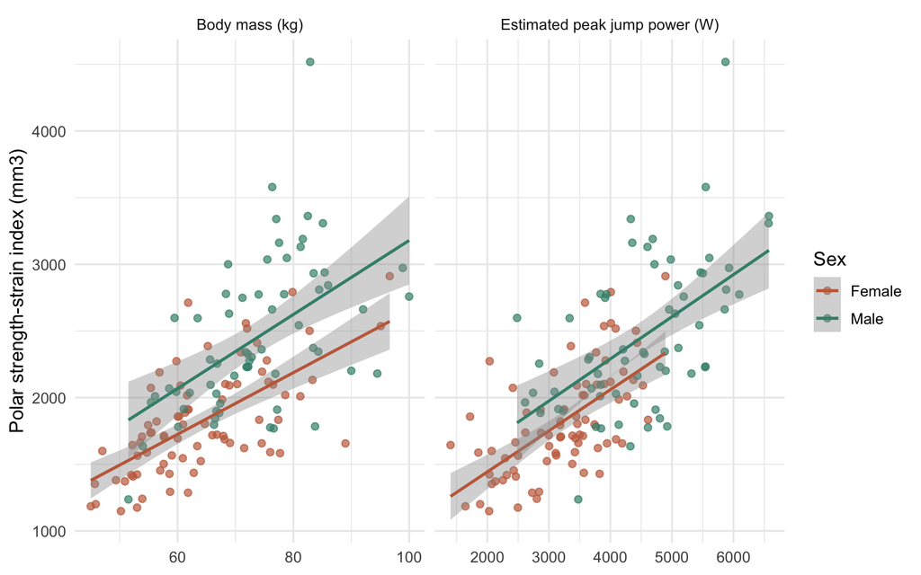

Figure 1. Polar strength-strain index against body mass and against estimated peak jump power, by sex.

Both body mass and estimated peak power track the polar strength-strain index strongly and in the same direction in each sex, and unlike the trabecular index the body-mass panel is at least as convincing as the power panel, which is the first hint that the cortical shaft responds to carried load rather than to explosive power alone.

## Univariable models

| **Characteristic** | **N** | **Beta** | **95% CI** | **p-value** |
| --- | --- | --- | --- | --- |
| Sex | 142 |  |  |  |
| Female |  | — | — |  |
| Male |  | 632 | 471, 793 | <0.001 |
| Age band (10-year bins) | 142 |  |  |  |
| Decade 2 |  | — | — |  |
| Decade 1 |  | 30 | -204, 265 | 0.8 |
| Decades 3-6 |  | -284 | -552, -17 | 0.038 |
| Body mass (kg) | 142 | 32 | 26, 38 | <0.001 |
| Estimated peak jump power (W) | 142 | 0.37 | 0.31, 0.44 | <0.001 |

Abbreviation: CI = Confidence Interval

Body mass and peak power are both strong crude predictors. Each additional kilogram of body mass is associated with 31.6 mm3 (95% CI 25.6 to 37.7) higher polar strength-strain index (p <0.001), and each additional watt of estimated peak power with 0.374 mm3 (95% CI 0.312 to 0.436) (p <0.001), i.e. 374 mm3 per 1000 W. Men average 632 mm3 (95% CI 471 to 793) higher than women (p <0.001). Participants in decades 3 to 6 average -284 mm3 (95% CI -552 to -17) relative to decade 2 (p = 0.038), while decade 1 is indistinguishable from decade 2 in the crude analysis (30 mm3 (95% CI -204 to 265), p = 0.798).

## Why adjustment is needed

**Body mass** confounds the crude peak-power association in a way that is unusually explicit in this dataset: heavier participants have higher estimated peak power partly because they jumped higher, but also partly by construction, since body mass enters the Sayers equation with a coefficient of 48.9 W per kilogram. Body mass is separately and powerfully associated with cortical bone because the shaft’s bending resistance adapts to the load it habitually carries, which is essentially body weight during walking, so a crude power coefficient is carrying a mass effect on both counts. **Sex** confounds the same association from the other direction: men in this sample are heavier (median 72.8 versus 61.7 kg) and more powerful (median 4552 versus 3380 W), and men have longer, thicker tibiae for reasons of skeletal size that have nothing to do with jumping, so the crude power slope is partly a comparison of men with women. **Age band** confounds in the opposite direction and is worth adjusting for even though its crude contrasts are unimpressive: the youngest participants are *lighter* (mean body mass 65.0 kg in decade 1 versus 70.1 kg in decade 2) and more often female (65% versus 49%), both of which push their cortical index down and mask whatever age pattern exists. Mutual adjustment lets each coefficient be read as a comparison between participants of the same sex, age band and body mass.

## Multivariable model

| **Characteristic** | **Beta** | **95% CI** | **p-value** |
| --- | --- | --- | --- |
| Sex |  |  |  |
| Female | — | — |  |
| Male | 288 | 129, 446 | <0.001 |
| Age band (10-year bins) |  |  |  |
| Decade 2 | — | — |  |
| Decade 1 | 198 | 39, 358 | 0.015 |
| Decades 3-6 | -44 | -229, 142 | 0.6 |
| Body mass (kg) | 17 | 7.5, 26 | <0.001 |
| Estimated peak jump power (W) | 0.15 | 0.04, 0.27 | 0.010 |

Abbreviation: CI = Confidence Interval

**Model fit: multivariable linear model for polar strength-strain index**

| Statistic | Value |
| --- | --- |
| Complete-case N | 142 |
| Parameters (excl. intercept) | 5 |
| Observations per parameter | 28.4 |
| R-squared | 0.583 |
| Adjusted R-squared | 0.568 |
| Residual SE (mm3) | 377.6 |

## Unadjusted versus adjusted

**Table 2. Unadjusted and adjusted estimates.**

| **Characteristic** | **Unadjusted** **N** | **Unadjusted** **Beta** | **Unadjusted** **95% CI** | **Unadjusted** **p-value** | **Adjusted** **Beta** | **Adjusted** **95% CI** | **Adjusted** **p-value** |
| --- | --- | --- | --- | --- | --- | --- | --- |
| Sex | 142 |  |  |  |  |  |  |
| Female |  | — | — |  | — | — |  |
| Male |  | 632 | 471, 793 | <0.001 | 288 | 129, 446 | <0.001 |
| Age band (10-year bins) | 142 |  |  |  |  |  |  |
| Decade 2 |  | — | — |  | — | — |  |
| Decade 1 |  | 30 | -204, 265 | 0.8 | 198 | 39, 358 | 0.015 |
| Decades 3-6 |  | -284 | -552, -17 | 0.038 | -44 | -229, 142 | 0.6 |
| Body mass (kg) | 142 | 32 | 26, 38 | <0.001 | 17 | 7.5, 26 | <0.001 |
| Estimated peak jump power (W) | 142 | 0.37 | 0.31, 0.44 | <0.001 | 0.15 | 0.04, 0.27 | 0.010 |

Abbreviation: CI = Confidence Interval

## Diagnostics

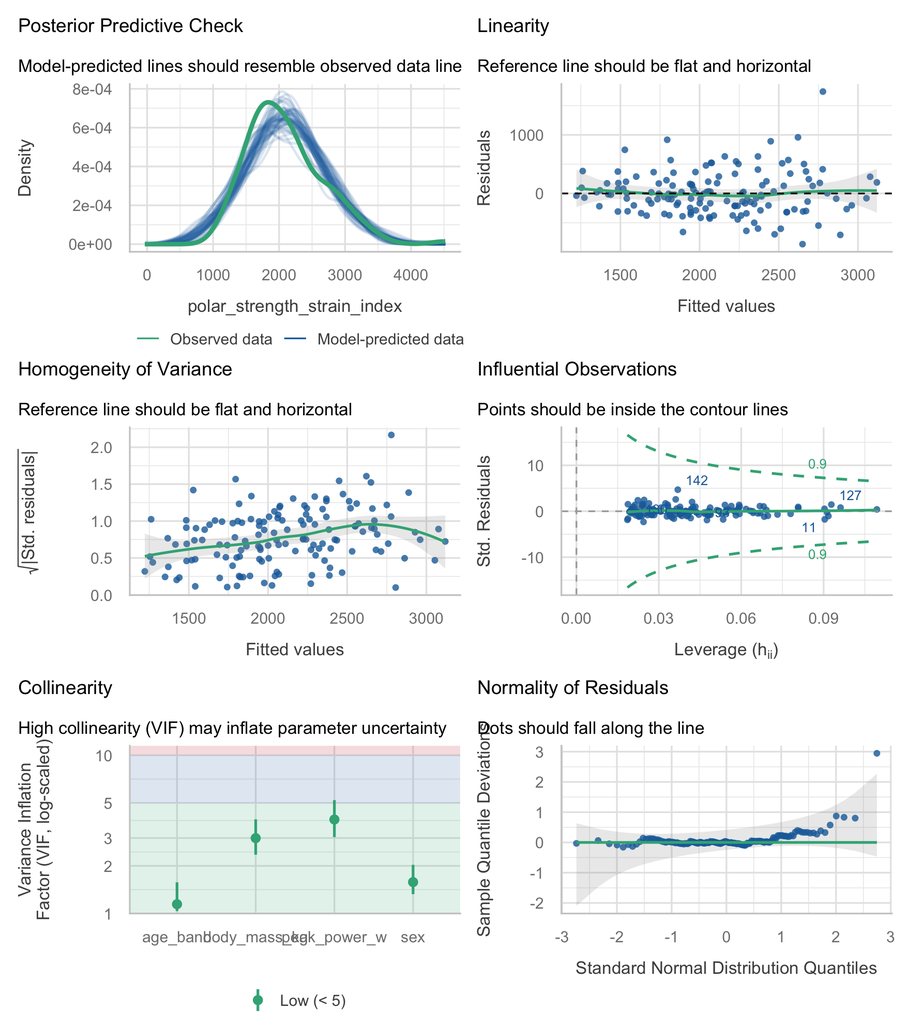

| Term | VIF | VIF_CI_low | VIF_CI_high | SE_factor | Tolerance | Tolerance_CI_low | Tolerance_CI_high |
| --- | --- | --- | --- | --- | --- | --- | --- |
| sex | 1.579331 | 1.325470 | 2.031200 | 1.256714 | 0.6331795 | 0.4923198 | 0.7544495 |
| age_band | 1.144973 | 1.036585 | 1.574474 | 1.034425 | 0.8733829 | 0.6351328 | 0.9647061 |
| body_mass_kg | 2.994820 | 2.354574 | 3.937680 | 1.730555 | 0.3339099 | 0.2539566 | 0.4247053 |
| peak_power_w | 3.929193 | 3.038890 | 5.208257 | 1.982219 | 0.2545052 | 0.1920028 | 0.3290675 |

**Table 3. Coefficients with and without the single most influential observation (Cook’s D = 0.141).**

| Term | Full sample | Most influential dropped | Change (%) |
| --- | --- | --- | --- |
| sexMale | 287.884 | 292.315 | 1.5 |
| age_bandDecade 1 | 198.370 | 216.337 | 9.1 |
| age_bandDecades 3-6 | -43.713 | -43.492 | 0.5 |
| body_mass_kg | 16.649 | 17.786 | 6.8 |
| peak_power_w | 0.151 | 0.118 | -22.0 |

**Table 4. HC3 heteroscedasticity-consistent standard errors.**

| Term | Estimate | SE (OLS) | SE (HC3) | 95% CI (HC3) | p (HC3) |
| --- | --- | --- | --- | --- | --- |
| sexMale | 287.884 | 80.162 | 77.351 | 134.92 to 440.85 | 0.000 |
| age_bandDecade 1 | 198.370 | 80.553 | 69.216 | 61.49 to 335.25 | 0.005 |
| age_bandDecades 3-6 | -43.713 | 93.768 | 77.129 | -196.24 to 108.81 | 0.572 |
| body_mass_kg | 16.649 | 4.603 | 4.866 | 7.03 to 26.27 | 0.001 |
| peak_power_w | 0.151 | 0.058 | 0.066 | 0.02 to 0.28 | 0.024 |

**Linearity and homogeneity of variance.** The residual-versus-fitted panel fans out clearly: participants with high fitted values have far more variable residuals than those with low ones, and `check_heteroscedasticity()` rejects constant variance (p <0.001). Table 4 therefore reports HC3 robust standard errors. Inference is not overturned - body mass keeps p <0.001, sex p <0.001, and peak power p = 0.024 - but the HC3 standard error for peak power is 0.066 against an OLS value of 0.058, i.e. wider, so the power coefficient is the least secure of the four.

**Normality of residuals.** The normal-QQ panel departs from the reference line in the upper tail and `check_normality()` **rejects** (p <0.001). This is the diagnostic that fails hardest, and it is driven by the same handful of very large tibiae that cause the variance to fan. The posterior-predictive check shows the corresponding symptom: the fitted normal predictive distribution is symmetric while the observed outcome is right-skewed.

**Collinearity.** The variance inflation factors are 3.93 for peak power and 2.99 for body mass, with sex at 1.58 and age band at 1.14. These stay below the conventional threshold of 5 but they are the direct price of the parameterisation chosen in Methods, and they are why the two dominant predictors each absorb roughly half of the other’s crude association.

**Influential observations.** This matters more here than for any other model in this dataset. The largest Cook’s distance is 0.141 - still far below the conventional concern threshold of 0.5, and the largest leverage is 0.109, with 7 observations exceeding the stricter 4/n rule. But Cook’s distance understates the problem for a single coefficient. Table 3 shows that refitting without that one participant moves the **peak-power coefficient from 0.151 to 0.118 mm3 per watt, a change of 22%**, while body mass moves only 6.8% and sex only 1.5%. The participant in question has the **highest polar strength-strain index in the sample** (4518 mm3, against a median of 2018) together with a peak power in the top 4% of the sample (5870 W); the model under-predicts them by 1740 mm3, and because they sit at the top of the power range that residual levers the power slope upward. The peak-power estimate remains significant without them (p = 0.029), so the conclusion survives, but at n = 142 a single participant moving a coefficient by a fifth is exactly the fragility that a small sample produces and it should be reported rather than hidden.

## Sensitivity: alternative parameterisations

**Table 5. The same data under five parameterisations of body mass and power.**

| Model | Parameters | R-squared | Adjusted R-squared | Residual SE | Max VIF |
| --- | --- | --- | --- | --- | --- |
| Chosen: body mass + absolute power | 5 | 0.583 | 0.568 | 377.6 | 3.9 |
| Equivalent: body mass + jump height | 5 | 0.583 | 0.568 | 377.6 | 1.7 |
| Alternative: body mass + relative power | 5 | 0.574 | 0.558 | 381.9 | 1.6 |
| Absolute power only (no body mass) | 4 | 0.543 | 0.530 | 393.9 | 1.6 |
| WRONG: all three power/mass terms | 6 | 0.610 | 0.593 | 366.7 | 89.0 |

Table 5 makes the argument of the Methods section concrete. The chosen model and the jump-height model have **identical** R-squared (0.583212 versus 0.583212) and identical residual standard error, because they are the same model written twice: multiplying the peak-power coefficient by 51.9 gives 7.830611, against a jump-height coefficient of 7.830611 mm3 per centimetre - the same number to six decimal places, not merely a similar one. Read this way, the adjusted power effect is a jump-height effect of 7.8 mm3 per centimetre jumped, and the body-mass coefficient becomes 24.0 mm3 per kilogram (p <0.001) rather than 16.6 - the same information, split differently between the two terms, which is precisely why the parameterisation has to be chosen deliberately and stated.

Substituting relative for absolute power costs a little fit (R-squared 0.574 against 0.583) and, more importantly, leaves the power term non-significant (p = 0.058), so for this outcome the two parameterisations do **not** lead to the same conclusion about muscle power. Dropping body mass altogether costs more (R-squared 0.543). The last row is the trap: entering body mass, absolute power *and* relative power together raises R-squared to 0.610 - which is exactly why a student would be tempted - while pushing the maximum variance inflation factor to 89. In that model relative power takes a coefficient of -54.6 mm3 per W/kg (p = 0.003) and body mass flips to -24.9; both are significant or near-significant and both are nonsense, since they say that being more powerful for one’s size and being heavier are each associated with *weaker* cortical bone. That is what near-perfect collinearity looks like when it is significant, and it is the single most dangerous thing a student can do with this dataset.

Because both the variance and the normality checks failed, we also refitted on the log scale. This resolves both problems - heteroscedasticity p = 0.276, normality p = 0.699 - and improves the fit (R-squared 0.617 against 0.583). The conclusions are unchanged in direction and significance: each kilogram of body mass is associated with 0.92% higher polar strength-strain index (p <0.001), each 1000 W of peak power with 5.8% (p = 0.028), and men with 15.0% higher (p <0.001). On the evidence of the diagnostics the log model is the better model for this outcome; the natural-scale model is retained as primary only because its coefficients are in the units the source paper uses, with HC3 standard errors doing the inferential work.

# Discussion

Among these 142 healthy adults, **body mass is the characteristic most strongly and independently associated with cortical bone strength at the tibial shaft** - about 17 mm3 per kilogram among participants of the same sex, age band and estimated jump power - with estimated peak power making a smaller but still independent contribution of about 151 mm3 per 1000 W. This is the mirror image of what the same four predictors show for the trabecular index at the distal tibia, where power dominates and body mass falls away entirely. The contrast is biologically coherent: the shaft’s job is to resist the bending moments generated by carrying body weight, whereas the distal end resists the compressive impacts generated by fast, forceful movement, and each site appears to track the loading it actually experiences. Practically, it cautions against treating “bone strength” as one thing; an intervention that improved jumping power would not necessarily do the same for both sites.

**Limitations.** The design is **cross-sectional**, so temporality is unknown and reverse causation cannot be excluded - people with larger, stronger tibiae are likely to have been more active for years, so the arrow may run from bone to power rather than the other way. The relationship with body mass is also open to a purely structural reading: bigger people have bigger bones, and a geometric index of a larger bone will be larger without anything adaptive happening; tibial length, which would allow this to be separated, is not in the file. The sample is a **convenience sample of one university’s staff and students**, young (63% in a single decade band) and healthy, so nothing here generalises to older adults or to anyone at real fracture risk, and the decade 1 finding rests on 31 participants. **Peak power was estimated, not measured**: it is the Sayers regression equation applied to jump height and body mass, and the jump heights are recorded to the nearest half inch, giving only 45 distinct values. Measurement error in a predictor attenuates its coefficient toward the null, so the true association with genuinely measured power is if anything stronger than reported; it also means the power variable is partly a restatement of body mass, which is why the two compete (VIF 3.9) and why the split of the association between them depends on the parameterisation. **Age is a decade bin, not a number.** Residual variance is non-constant *and* residuals are non-normal; HC3 addresses inference and the log model addresses both, but the natural-scale model does not fit the upper tail. At n = 142 the peak-power coefficient moves by 22% when the single most influential participant is removed, so that estimate in particular should be read as provisional. Physical activity, diet, tibial length, limb dominance and hormonal history are **not measured**, so residual confounding is certain. All estimates are associations, not causal effects.

**Future work.** A study with directly measured force-plate power and tibial length would separate the geometric size effect from the loading effect, which is the ambiguity this analysis cannot resolve.

# Feasibility notes

*NOT part of a student report.*

- **USABLE WITH WARNINGS.** The outcome is complete, the model is well specified at 28.4 observations per parameter and the fit is the best in the dataset (R-squared 0.58), but **two diagnostics fail** and one coefficient is materially sensitive to a single participant. The warnings are all reportable rather than fatal.
- **MAJOR: both heteroscedasticity (p <0.001) and non-normality of residuals (p <0.001) fail.** This is worse than the companion trabecular outcome, where normality passes. A log transform fixes both (p = 0.276 and p = 0.699) and raises R-squared from 0.583 to 0.617, so the honest answer is that this outcome should be modelled on the log scale. A student who reports the raw-scale model with no transformation and no robust standard errors has two failed checks on the record.
- **MAJOR: one participant moves the peak-power coefficient by 22%.** Dropping the observation with the largest Cook’s distance (0.141, the participant with the highest outcome value in the file and a peak power in the top few per cent) changes the estimate from 0.151 to 0.118. Cook’s distance alone does not flag it, because 0.141 looks reassuring next to the 0.5 rule of thumb; the leave-one-out refit is what exposes it. At n = 142 this check should be mandatory, and students should be told to do it rather than to trust the Cook’s distance panel.
- **MAJOR trap: `peak_power_w` and `relative_peak_power` are the same variable.** `relative_peak_power` is exactly `peak_power_w / body_mass_kg` rounded to 2 dp (largest discrepancy across all 142 rows: 0). This outcome is where the trap bites hardest, because putting all three of body mass, absolute power and relative power in one model **raises R-squared** from 0.583 to 0.610 and returns *significant* coefficients (relative power -54.6, p = 0.003) with VIFs of 89, 36 and
  31. A student chasing R-squared will build this model, get significant results, and write nonsense about heavier people having weaker cortical bone. The catalogue’s own suggested predictor list contains **both** power variables, so this must be flagged in `meta.json`.
- **MAJOR trap: `peak_power_w` already contains `body_mass_kg`.** It is the Sayers (1999) equation, `PP = 51.9*jump_cm + 48.9*body_mass - 2007`, inverted; the recovered jump heights land on a half-inch grid to within 0.00008 and reproduce `peak_power_w` to 0.005 W. Because of this, the model with body mass and absolute power is *algebraically the same* as the model with body mass and jump height, and the two terms split the association differently under each parameterisation (body mass 16.6 versus 24.0 mm3/kg). The parameterisation is a choice, not a detail, and it must be justified in Methods.
- **MAJOR: the choice of power variable changes the conclusion for this outcome.** With absolute power the power term is significant (p = 0.010); with relative power in its place it is not (p = 0.058). Two students making different, individually defensible choices will write different discussions. This is unavoidable given the data, but markers should expect it.
- **MAJOR: `age_decade` cannot be used as a six-level factor.** Cell sizes are 31, 89, 9, 6, 5, 2 for decades 1 through 6, so decade 6 holds 2 participants and there are no men at all in decades 4 or 6. As a six-level factor the largest standard error is 284 mm3 and the extra three degrees of freedom buy nothing (F test against the collapsed model p = 0.97). Collapsing to three bands is required, not optional.
- **MINOR: the decade 1 coefficient appears only after adjustment.** It goes from 30 mm3 (p = 0.798) crude to 198 mm3 (p = 0.015) adjusted, on 31 participants. It is a genuine masking effect (that band is lighter and more often female) but it is fragile and a student who leads on it is over-reaching.
- **MINOR: no binary outcome exists in this file, and none should be manufactured.** A student will be tempted to split the polar strength-strain index at its median or a percentile to run a logistic model. There is **no clinical threshold** for SSI in healthy adults - it has no diagnostic cut-point, no reference population and no fracture-risk calibration - so any dichotomy would be arbitrary, would discard the information that gives this model its R-squared of 0.58, and would produce an “outcome” that answers no question anyone asks. The dataset supports a **linear project only**, and `index.html` correctly says so.
- **MINOR: the two outcomes are correlated at 0.69** (Pearson), i.e. they share 48% of their variance, and the residual correlation after this model is 0.45. They are **not** redundant and both should stay in the catalogue: the two analyses reach genuinely different conclusions - body mass dominates the shaft (16.6 mm3/kg, p <0.001) while it is null at the distal site, and peak power dominates the distal site while it is the weaker of the two here.
- **Sample size is the binding constraint.** 142 participants and five candidate predictors, two of which cannot coexist, leaves essentially one sensible model. There is no room for interactions, splines or subgroup analyses, and students should be told that plainly rather than discovering it.